# AE 09

Hypothesis Testing using Simulation

Scott Burstein

Due: Sep 25, 11:59 PM

## Clone a repo + start a new project

Go to the `ae09-[GITHUB USERNAME]` repo, clone it, and start a new project in RStudio. See the earlier labs and application exercises for detailed instructions.

## Configure git

Run the following code to configure Git. Fill in your GitHub username and the email address associated with your GitHub account.

```r
library(usethis)
use_git_config(user.name= "sburstein", user.email="scott.burstein@duke.edu")
```

# Packages and data

```r
library(tidyverse)
hand <- read_csv("data/handedness.csv")
```

# Exercises

The `handedness` dataset contains the handedness of a random sample of 77 Duke students (one mixed-handed student was asked to choose which hand they primarily used to brush their teeth).

Based on previous research, 11 percent of the world is left-handed (Hardyck and Petrinovich, 1977 *Psychological Bulletin*). You are interested in whether Duke has a higher proportion of left-handed students than would be expected from the world average.

```r
hand %>%
  count(handedness) %>%
  mutate(prop = n / sum(n))
```

```
## # A tibble: 2 x 3
##   handedness     n  prop
##   <chr>      <int> <dbl>
## 1 left          16 0.208
## 2 right         61 0.792
```

The proportion of Duke students from the sample who are left handed is 16/77 = 0.21

1. Write in both words and symbols the population parameter and point estimate.

The population parameter is the true unknown proportion of Duke students who are left-handed.

The point estimate is the sample proportion of Duke students who are left-handed.

The sample proportion is 0.2077922

```r
round(16/77, 2)
```

```
## [1] 0.21
```

2. Is it feasible to determine the parameter in this example? Why or why not?

It is not feasible to determine the Duke population parameter in this example, because this would require data on every student, which is not currently available and likely difficult to obtain.

3. Write in both words and symbols the null and alternative hypotheses.

Null Hypotheses (Ho): p = 0.11 The proportion of Duke students that are left handed is not significantly different from the proportion of people that are left handed globally. There is no measurable and thus meaningful deviation from the global proportion of left handed individuals.

Alternative Hypotheses (Ha): p > 0.11 The proportion of Duke students that are left handed is significantly different from the proportion of people that are left handed globally. There is a measurable and thus meaningful deviation from the global proportion of left handed individuals.

Null and alternative hypothesis should never consider p-hat $\hat{p}$!

4. Conduct a simulation-based test of the hypotheses in Exercise #3 using 5000 simulations and a random seed of `42`.

```r
set.seed(42)
number_sims <- 5000
outcomes <- c("left", "right")

simulated_props <- numeric(number_sims)

for (i in 1:number_sims) {
  sim <- sample(outcomes, 77, prob = c(.11, .89), replace = TRUE)
  simulated_props[i] <- sum(sim == "left") / length(sim)
}
```

5. Create a well-labeled, effective visualization of the null distribution you obtained via simulation.

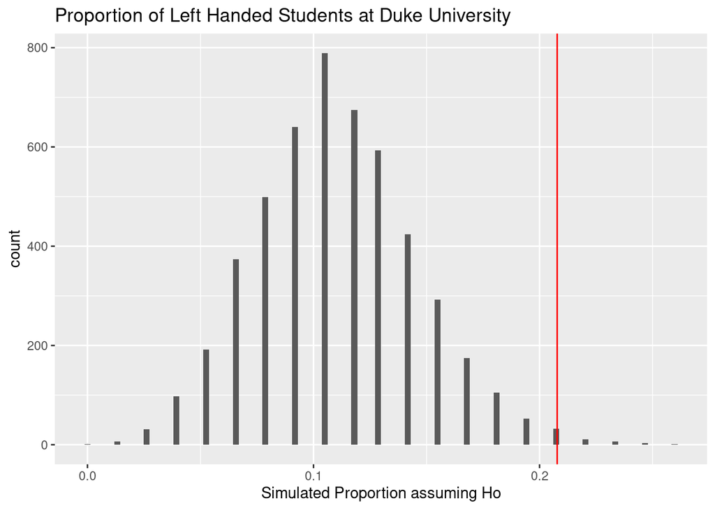

```r
simulated_props_data <- tibble(props = simulated_props)

ggplot(simulated_props_data,
    aes(x = props)) +
  geom_histogram(bins = 100) +
  geom_vline(xintercept = (16 / 77), color = "red") +
  labs(x = "Simulated Proportion assuming Ho",
       title = "Proportion of Left Handed Students at Duke University")
```

6. Carefully consider your visualization from Exercise #5. Where is it centered? What is the spread? Generally, does it behave the way you expect?

7. “Eye-ball” your visualization to estimate the p-value.

The p-value must be around 0.05 or less, since the vast majority of the data lies on the side of the curve closer to the mean.

8. Report your p-value using code.

```r
simulated_props_data %>%
  filter(props >= (16/77)) %>%
  summarize(p_value = n() / nrow(simulated_props_data))
```

```
## # A tibble: 1 x 1
##   p_value
##     <dbl>
## 1  0.0106
```

```r
#More elegant but not in line with 'tidyverse' syntax
#simulated_props_data %>%
#  summarize(p_value = mean(props >= (16/77)))
```

9. Provide a conclusion in the context of the problem.

Practice using ifelse() - does same as casewhen but more simple.

```r
hand %>%
  mutate(hand_new = ifelse(handedness == "left", "left-handed", "right-handed"))
```

```
## # A tibble: 77 x 2
##    handedness hand_new
##    <chr>      <chr>
##  1 left       left-handed
##  2 left       left-handed
##  3 left       left-handed
##  4 left       left-handed
##  5 left       left-handed
##  6 left       left-handed
##  7 left       left-handed
##  8 left       left-handed
##  9 left       left-handed
## 10 left       left-handed
## # … with 67 more rows
```